# Team 3 - Lab 5

Dynamic Linear Models (DLMs) - Time-varying productivity of salmon

Emma Christman, Brian McGreal, Anna Sulc

May 27, 2025

# Data

## Load the data

This exercise involves spawner-recruit data for sockeye salmon (Oncorhynchus nerka) from the Kvichak River in SW Alaska that span the years 1952-2005. We have a dataframe with columns for brood year (`brood_year`), number of spawners (`spawners`), number of recruits (`recruits`) and PDO at year $t-2$ in summer (`pdo_summer_t2`) and in winter (`pdo_winter_t2`).

```
## # A tibble: 6 × 5
## # Groups:   brood_year [6]
##   brood_year spawners recruits pdo_summer_t2 pdo_winter_t2
##        <dbl>    <dbl>    <dbl>         <dbl>         <dbl>
## 1       1952       NA    20200         -2.79         -1.68
## 2       1953       NA      593         -1.2          -1.05
## 3       1954       NA      799         -1.85         -1.25
## 4       1955       NA     1500         -0.6          -0.68
## 5       1956     9440    39000         -0.5          -0.31
## 6       1957     2840     4090         -2.36         -1.78
```

We’ll take a quick look at spawners and recruits over time in the data.

[figure not shown]

## Wrangle the data

Before constructing DLMs to be solved using a MARSS model framework, some data cleaning is in order. A variable $y$ is constructed by taking the natural log of recruits divided by spawners ($\ln(R_t/S_t)$). The spawner variable $S_t$ is then scaled to be used as an inidcator variable in the model specification. Finally, because $S_t$ will act as an indicator variable, any observations with missing values in $S_t$ must be dropped, meaning in this case losing the first four observations in the time series. Because $y$ is constructed using the term $(R_t/S_t)$, any observations missing recruit values will also be dropped, as the resulting $y$ terms are NA, meaning we lose the last seven observations in the time series. This leaves us with complete data for 43 time steps.

```r
# transform data
data$y <- log(data$recruits/data$spawners)
data <- data[!is.na(data$spawners),]
data <- data[!is.na(data$recruits),]

years <- data$brood_year
TT <- length(years)
dat <- matrix(data$y, nrow=1)

s <- data$spawners
s_z <- matrix((s - mean(s))/sqrt(var(s)), nrow = 1)
m <- dim(s_z)[1] + 1
```

# Methods

### Base Model structure

We began by fitting a reduced form of Ricker’s model that including only a time-varying intercept ($\alpha_t$) as well as a time-varying effect of spawner abundance ($/beta_t$). That is,

$$\ln\left(\frac{R_t}{S_t}\right) = \ln(\alpha_t) + \beta_tS_t+ v_t$$

By setting $\ln\left(\frac{R_t}{S_t}\right)$ = $y_t$ and $\ln(\alpha_t)$ = $a_t$ we are left with the following observation equation:

$$\begin{align*}
\text{Linear Model:} \quad & y_t = a_t + \beta_tS_t+ v_t \\
& \quad v_t \sim \mathcal{N}(0, R) \\[1em]
\end{align*}$$

By then assuming that $a_t$ and $\beta_t$ are results of two unoberserved underlying processes, we may specify the following state equations:

$$\begin{align*}
\text{Parameters:} \quad & a_t = a_{t-1} + w_{a,t}, \quad w_t
\sim \mathcal{N}(0, Q_a) \\
& \beta_t = \beta_{t-1} + w_{\beta,t},
\quad w_t \sim \mathcal{N}(0, Q_\beta) \\
\end{align*}$$

This model assumes no density-dependent survival in that the number of recruits is an ascending function of spawners. We did not include any environmental variables for this step.

```r
# build MARSS model
# process
B <- diag(m)
U <- matrix(0, nrow=m, ncol=1)
Q <- matrix(list(0), m, m)
diag(Q) <- c("q.alpha", "q.beta")

# obs
Z <- array(NA, c(1, m, TT))
Z[1,1,] <- rep(1, TT)
Z[1,2,] <- s_z
A <- matrix(0)
R <- matrix("r")

# initital values & controls
inits <- list(x0 = matrix(c(0,0), nrow = m))
con_list <- list(maxit = 2146)
  # 2146 seems to be the minimum number of iterations at which all beta parameter varainces converge to zero

# model list
dlm.list <- list(B=B, U=U, Q=Q, Z=Z, A=A, R=R)

# fit model
if(!file.exists(here::here("Lab-5", "Team-3", "data", "dlm.rds"))){
  dlm <- MARSS(dat, model= dlm.list, inits = inits, method = "kem", control = con_list)
  saveRDS(dlm, file=here::here("Lab-5", "Team-3", "data", "dlm.rds"))
}
# load in ssm.phyto_month
dlm <- readRDS(file=here::here("Lab-5", "Team-3", "data", "dlm.rds"))
```

```
##
## MARSS fit is
## Estimation method: kem
## Convergence test: conv.test.slope.tol = 0.5, abstol = 0.001
## Estimation converged in 1961 iterations.
## Log-likelihood: -51.80292
## AIC: 113.6058   AICc: 115.2275
##
##           Estimate
## R.r         0.2028
## Q.q.alpha   0.3127
## Q.q.beta    0.0000
## x0.X1       1.0101
## x0.X2       0.0342
## Initial states (x0) defined at t=0
##
## Standard errors have not been calculated.
## Use MARSSparamCIs to compute CIs and bias estimates.
```

Below is a plot of estimated $a_t$ values across the study period. The model’s 95% confidence interval is fairly tight around the mean estimate at all points.

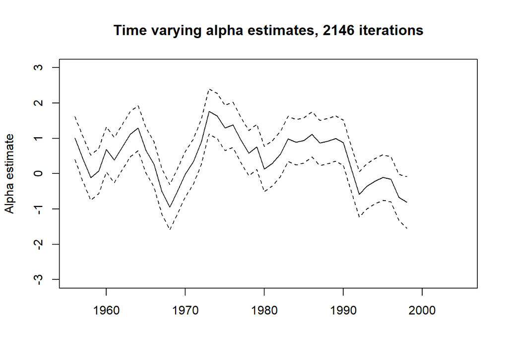

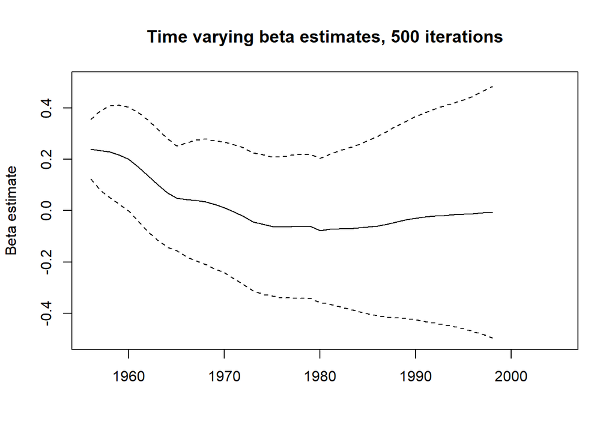

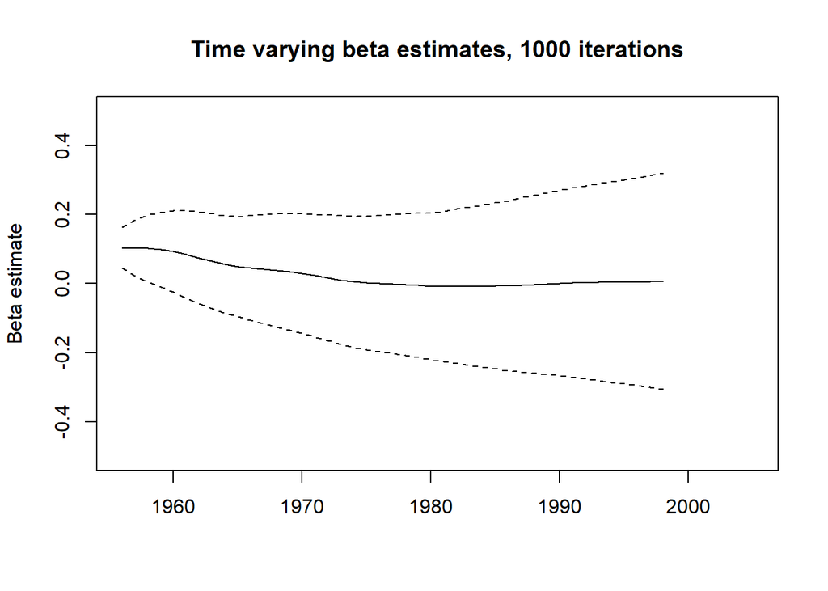

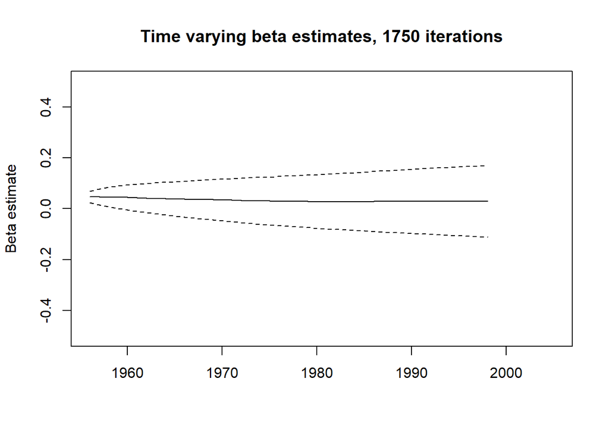

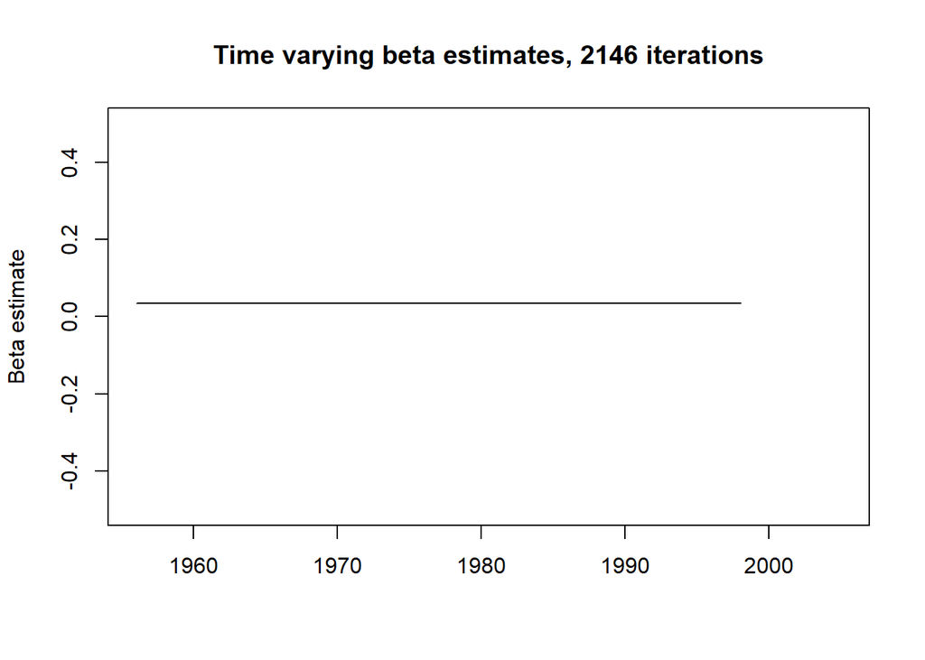

This may be due to the number of spawners having some “true” linear fixed effect on $\ln(R_t/S_t)$ which does not vary through time even when that flexibility is allowed by a modeling approach.

### Covariates

Next,we fitted the same Ricker model but included covariate terms meant to control for the effect of ocean climate on the outcome spawner-recruit ratio. The model includes $d_t$ as input covariate data and $D$ as the effect of said covariates on the coutcome.

The equation for this model is now:

$$\begin{align*}
\text{Linear Model:} \quad & y_t = a_t + \beta_tS_t+ Dd_t + v_t \\
& \quad v_t \sim \mathcal{N}(0, R) \\[1em]
\text{Parameters:} \quad & a_t = a_{t-1} + w_{a,t}, \quad w_t
\sim \mathcal{N}(0, Q_a) \\
& \beta_t = \beta_{t-1} + w_{\beta,t},
\quad w_t \sim \mathcal{N}(0, Q_\beta) \\
\end{align*}$$

WINTER PDO

```
##
## MARSS fit is
## Estimation method: kem
## Convergence test: conv.test.slope.tol = 0.5, abstol = 0.001
## Estimation converged in 1264 iterations.
## Log-likelihood: -51.38573
## AIC: 114.7715   AICc: 117.1048
##
##           Estimate
## R.r         0.1956
## Q.q.alpha   0.3112
## Q.q.beta    0.0000
## x0.X1       1.1379
## x0.X2       0.0069
## D.pdo       0.1537
## Initial states (x0) defined at t=0
##
## Standard errors have not been calculated.
## Use MARSSparamCIs to compute CIs and bias estimates.
```

SUMMER PDO

Of interest here, this model converges quickly but unlike in the other three specifications, $Q_\beta$ does not converge at zero.

```
##
## MARSS fit is
## Estimation method: kem
## Convergence test: conv.test.slope.tol = 0.5, abstol = 0.001
## Estimation converged in 90 iterations.
## Log-likelihood: -52.17034
## AIC: 116.3407   AICc: 118.674
##
##           Estimate
## R.r         0.1056
## Q.q.alpha   0.3694
## Q.q.beta    0.0155
## x0.X1       0.8855
## x0.X2       0.5201
## D.pdo      -0.0509
## Initial states (x0) defined at t=0
##
## Standard errors have not been calculated.
## Use MARSSparamCIs to compute CIs and bias estimates.
```

WINTER AND SUMMER PDO

```
##
## MARSS fit is
## Estimation method: kem
## Convergence test: conv.test.slope.tol = 0.5, abstol = 0.001
## Estimation converged in 1755 iterations.
## Log-likelihood: -51.1838
## AIC: 116.3676   AICc: 119.5676
##
##           Estimate
## R.r         0.2089
## Q.q.alpha   0.2880
## Q.q.beta    0.0000
## x0.X1       1.0651
## x0.X2       0.0125
## D.pdoW      0.2609
## D.pdoS     -0.1293
## Initial states (x0) defined at t=0
##
## Standard errors have not been calculated.
## Use MARSSparamCIs to compute CIs and bias estimates.
```

Model fit is compared using AICc. These models are all very close in AICc score but the null model with no PDO covariates exhibits the best fit. This would seem to imply that the addition of PDO does not improve model fit substantially enough to make up for the additional parameters the model must estimate.

```
## [[1]]
##           Model     AICc
## 1 no covariates 115.2275
##
## [[2]]
##        Model     AICc
## 1 winter PDO 117.1048
##
## [[3]]
##        Model    AICc
## 1 summer PDO 118.674
##
## [[4]]
##                   Model     AICc
## 1 winter and summer PDO 119.5676
```

Diagnostics on the on the models show above are compared here.

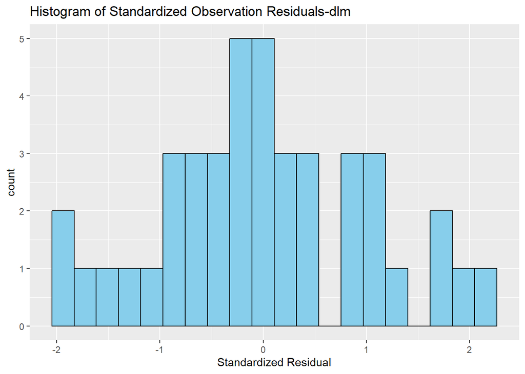

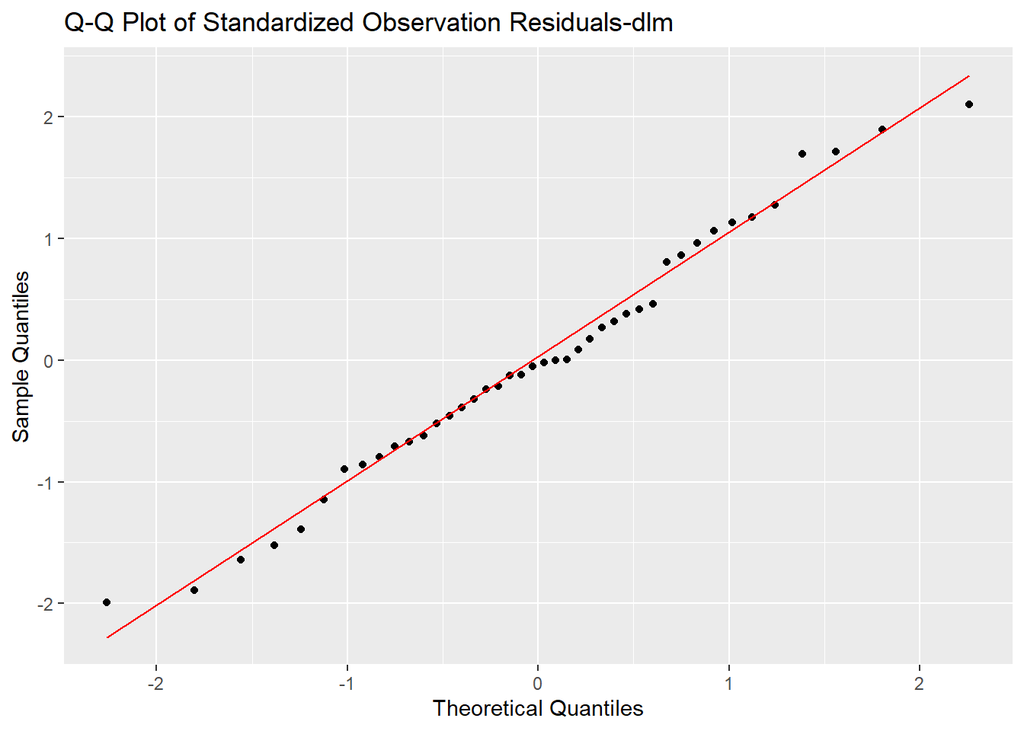

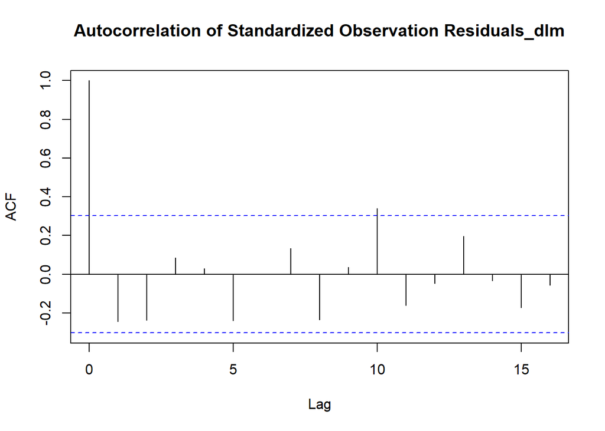

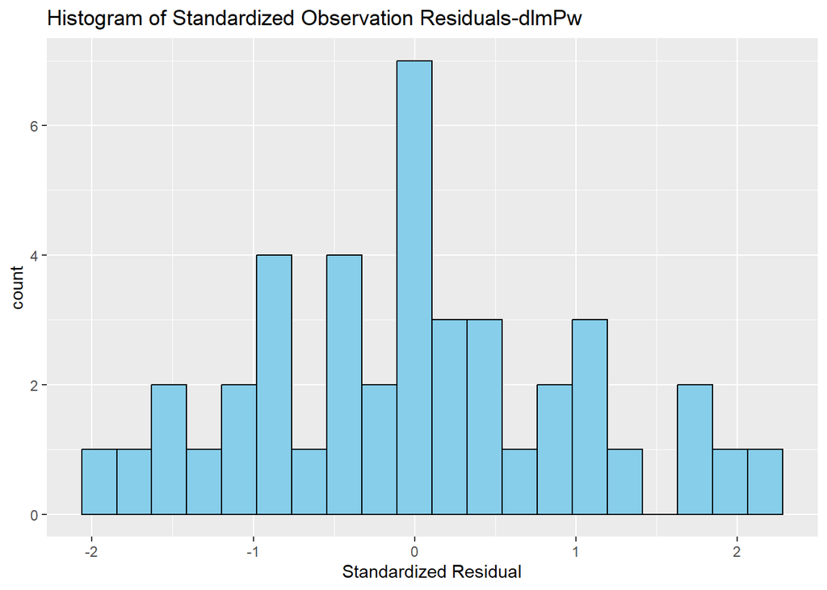

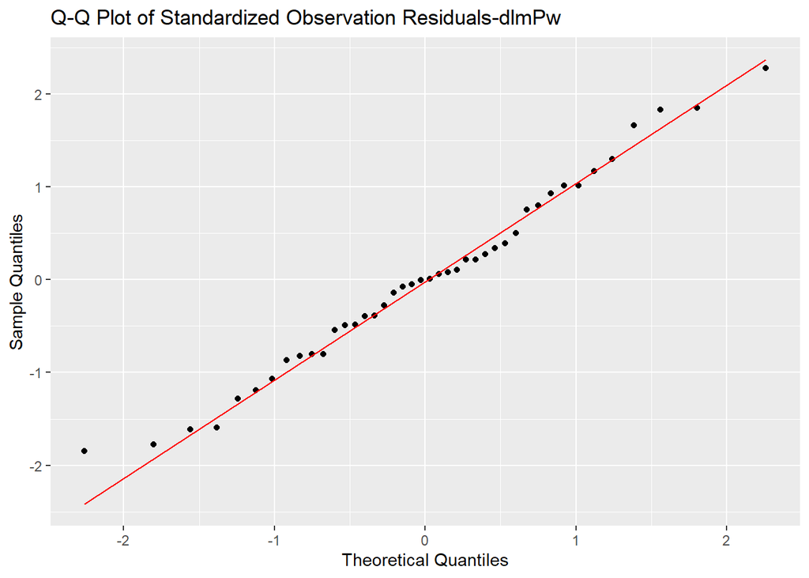

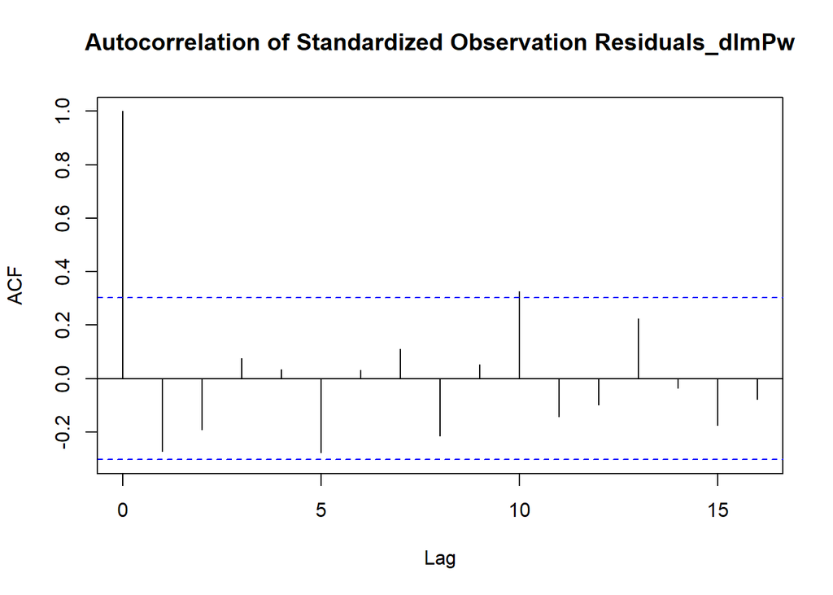

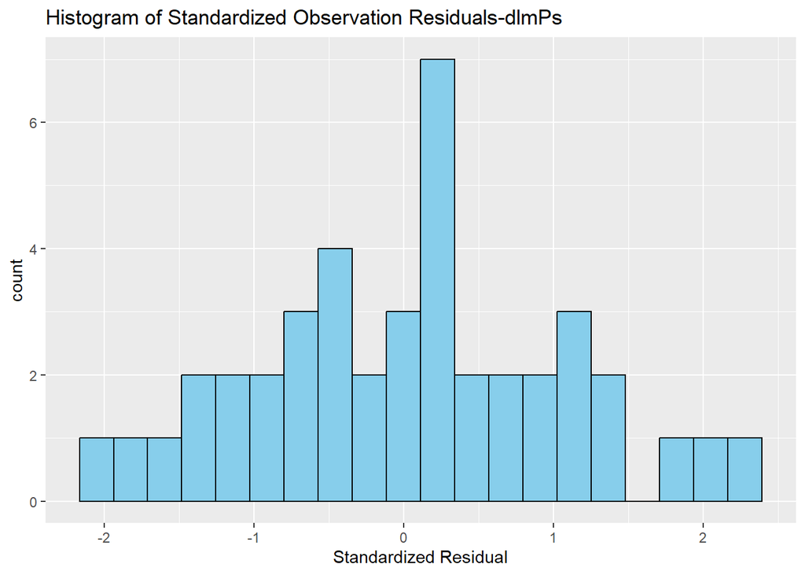

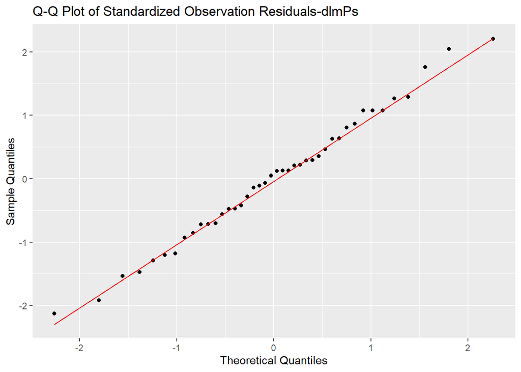

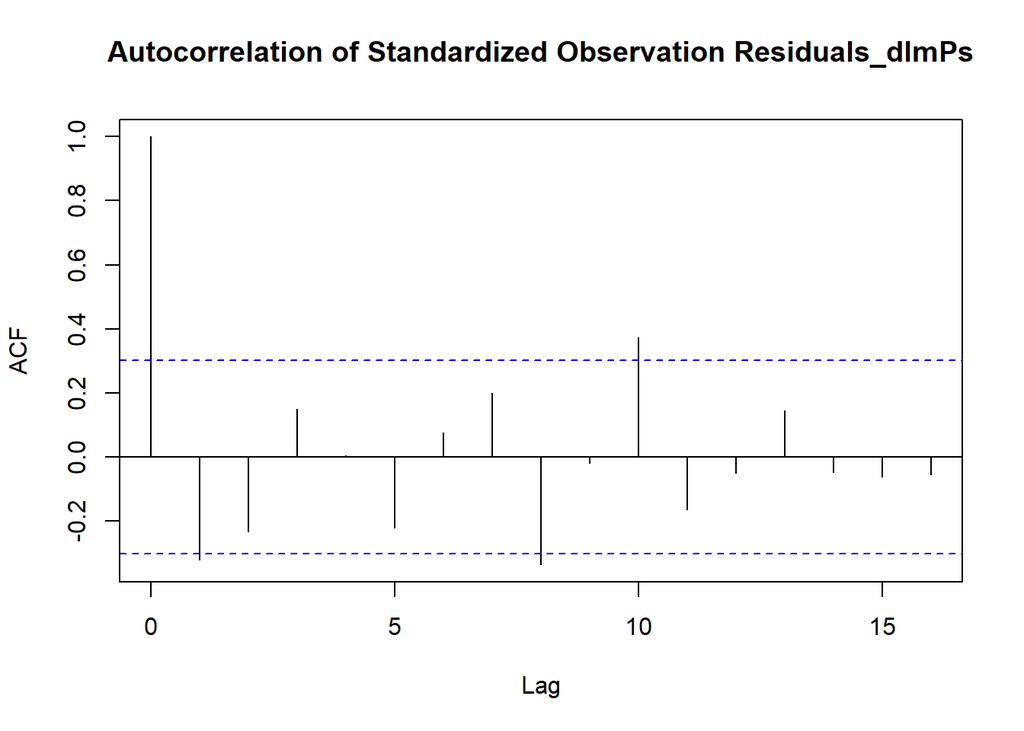

[figure not shown]

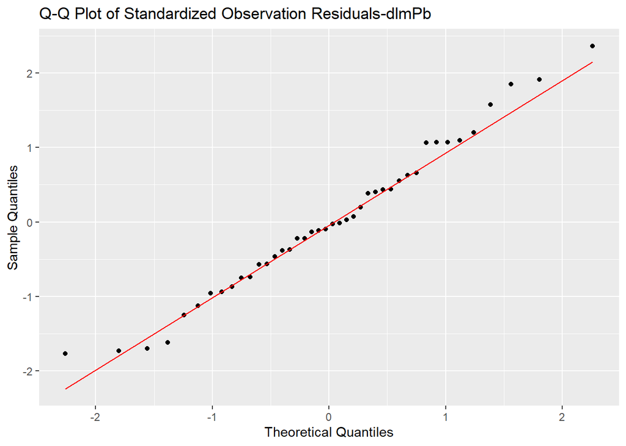

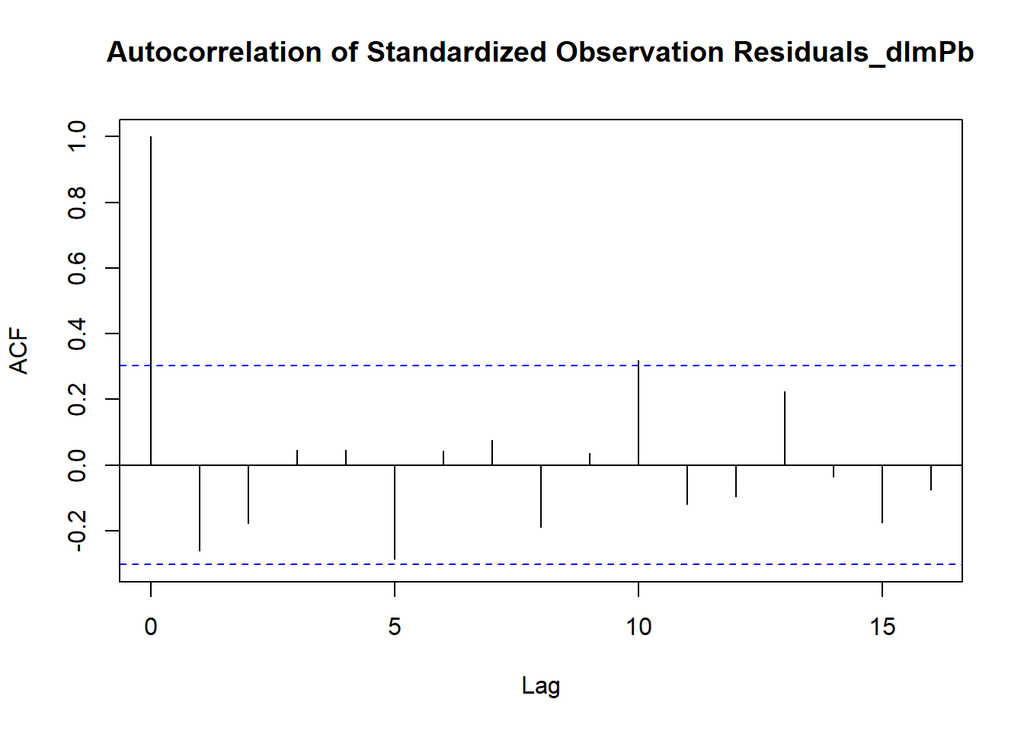

Similar to the null model, estiamtes of alpha in all models with covariates show fairly tight confidence intervals around a time-varying mean.

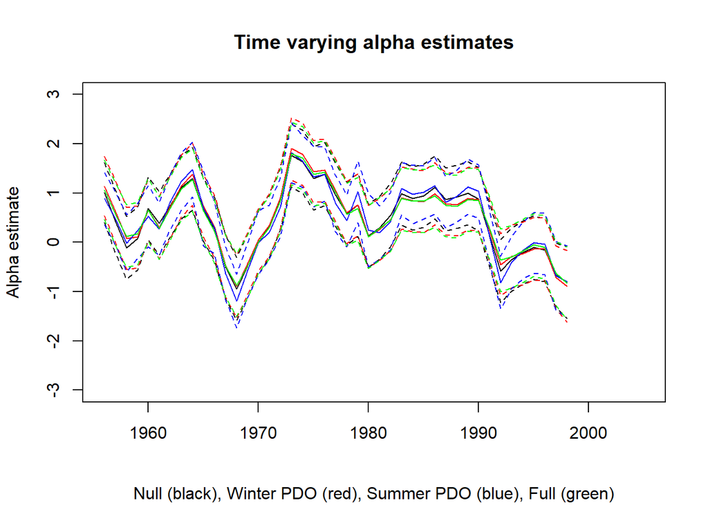

Here we see that, in two covariate models along with the null model, $Q_\beta$ has converged to zero and the model has reutrned a time-invarying estimate of the effect of spawners on $\ln(R_t/S_t)$. The summer PDO model sees $Q_\beta$ converge at 0.0155, leaving the parameter some latitude to vary across the study period. This suggests that including summer PDO (and only summer PDO) controls for some of the time-varying structure of $\ln(R_t/S_t)$ and allows $\beta_t$ to vary throughout time. Nonetheless, the null model retains the best fit.

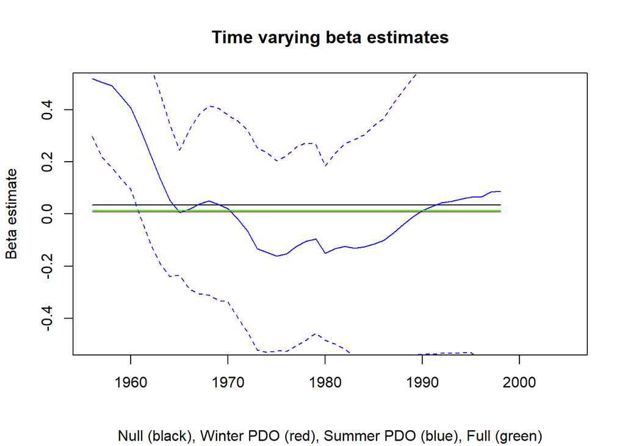

# Results

# Discussion

The results of these four models suggest that there is not a strong effect of PDO on the productivity of Kvichak sockeye, based only on the R/S rates over time. Although neither the winter or summer PDO models were considered the “best performing”, the winter PDO model showed slightly better performance than the summer. This could be the case because winters at sea may act as a slight bottleneck (as assumed) for survival of Kvichak fish. Summers are typically reliably productive for salmon, as with winter is already a time of slowed growth for fish, and thus the effect of the winter PDO signal may have more of an effect on fish. Besides the effect of PDO, there are other strong environmental signals that may be affecting the productivity of Kvichak sockeye, such as other climate variables including SST/Marine Heatwaves. Additionally, at sea there there is both inter- and intra-specific competition for resources, especially in recent years where the number of sockeye salmon in the ocean has been increasing, as well as the presence of Pink salmon, a major competitor of sockeye. One factor not discussed in this lab as well is the effect of catch on these returning fish. Although escapement goals are set by ADF&G, the number of spawning fish that are able to return to spawning grounds may be affected by the amount of fish caught in the fishery in Bristol Bay.

# Team contributions

All team members contributed to the data wrangling and analysis. We each attempted all sections of the lab and then reconvened to compared differences and merge scripts. Each team member contributed text to results and discussion sections.